# NHANES Manual Reproduce

#### Step 4. Women’s heart health by race equity plot

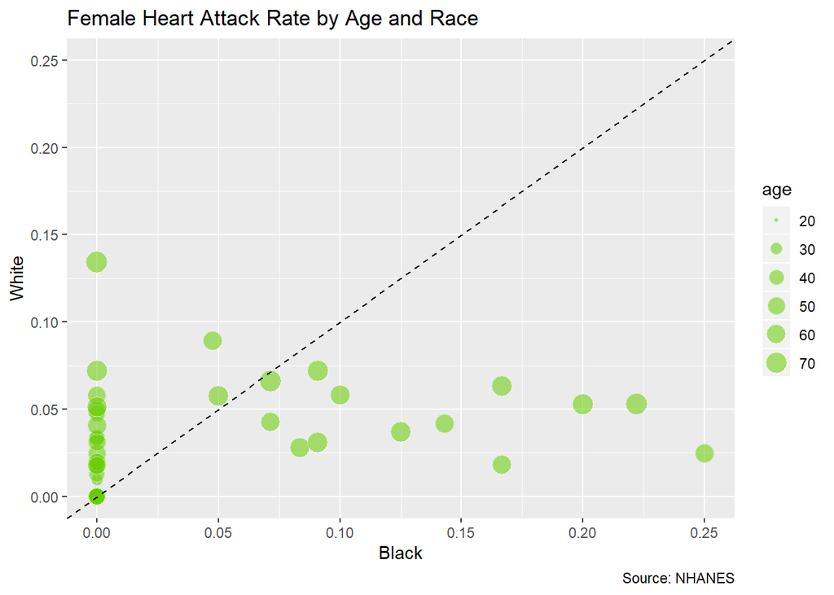

```r
nhanes <- read.dta13("http://www.stata-press.com/data/r14/nhanes2.dta")

# Filtering and subsetting NHANES data
subdata <- nhanes    %>%
  filter ((race == "White" | race =="Black")& (sex=="Female"))%>%
  subset(select=c(heartatk,race,age))

# Summarize heart rate risk by age
metadata<-subdata %>%
  group_by(age, race) %>%
  summarize(heartatk_rate = mean(heartatk, na.rm = TRUE))

# Reshaping the NHANES by age data
spreaddata <-  metadata %>%
  spread( key = c(race), value=heartatk_rate)

# Plotting female heart attack rate for black and white with age sized dots
# Add an abline and change the scale of axes to be consistent and show line of equal outcomes


ggplot(spreaddata, aes(x=Black, y=White))+
  geom_point(colour="white", fill="chartreuse3", shape=21, alpha=.55, aes(size=age))+
  geom_abline(intercept = 0, slope = 1, linetype=2)+
  scale_x_continuous(limits=c(0,.25))+
  scale_y_continuous(limits=c(0,.25))+
  labs(title="Female Heart Attack Rate by Age and Race",
       Subtitle="Ages: 50 to 75, Average Rates",
       caption="Source: NHANES",
       x="Black",
       y="White")
```

#### Step 5. Bundle for easy reproducibility

5. Bundle this using packrat using ::bundle, just as you did ::init at start.

```r
packrat::bundle
source(here("src", "script2.R"))
```

```
## The packrat project has been bundled at:
## - "C:\Users\Claud\Box\A3SR Social Impact\repro_NHANES_manual\packrat\bundles/repro_NHANES_manual-2019-11-11.tar.gz"
```

#### Step 6. Review, check for errors, and share

6. Create a title for your results that adequately describes your analysis. Review your output - are results sensible? Check knitted output, writing, and formatting for legibility. Bonus points if you can implement a shareable version control system such as github alongside packrat. Share your results.

Thank you for reading. Please feel free to make changes and provide feedback on this manual.